# Predicting customers’ probability of default

Daniela Orovwiroro

7/2/2019

# Case Study for Data Scientist Role

## NAD Marketing Insights and Analytics

Credit lending involves any form of deferred payment extended by a creditor or credit facility to a debtor. This is an important business area for financial institutions. There is a risk that some customers may use their credit card beyond their repayment capabilities which would translate to high debt accumulation. Hence, there is need to identify the risky and non-risky customers and the potential of the customers to repay the debt. This is a case study to use data on Consumer credit usage that contains credit line granted to a customer, their payment and balance history, demographics and their default status to predict customers’ probability of default.

Key Problems And Issues In The NAD Marketing Case Study Some consumers issued credit by the company have a history of payment defaults.

Data on customers and their default status have been collected and this requires data processing

NAD may face risk exposure of some customers using their credit line beyond their repayment capabilities which would translate to high debt accumulation.

Hence, there is need to identify and predict risky and non-risky customers and identify the potential of the customers to repay the debt.

## Step 1: Data Cleansing

Data cleansing is important because it involves the preparing of data for analysis by removing or modifying data that is incorrect, incomplete, irrelevant, duplicated, or improperly formatted. This improves the data quality, and this translates to overall productivity. Cleaning data by removing duplicates, marking missing values and imputing missing values.

```r
# We will load the libraries
library(tidyverse)  # data manipulation
library(cluster)    # clustering algorithms
library(factoextra) # clustering algorithms & visualization
library(MASS)
library(caret)   # Classification and Regression Training
```

```r
library(dplyr)   # A Grammar of Data Manipulation
library(pROC)    # Display and Analyze ROC Curves
library(lmtest)  # Testing Linear Regression Models
library(e1071)   # Tuning of Functions Using Grid Search, Support Vector Machines
library(sandwich)    # Robust Covariance Matrix Estimators
library(rpart.plot)  # Decision Tree
library(dummies)
library(psych)
library(corrplot)
library(gridExtra)
library(grid)
library(lattice)
library(sqldf)
library(ROCR)
# Set work directory
setwd("C:/Users/Daniela Orovwiroro/Desktop/credit")
# Import the credit dataset
credit = read.csv("data.csv",sep=",", header=TRUE, stringsAsFactors = FALSE)

# Examine the imported credit dataset.
dim(credit)
```

```
## [1] 30000    24
```

```r
# Review the first 6 rows of credit dataset.
head(credit)
```

```
##       X1 X2 X3 X4 X5 X6 X7 X8 X9 X10 X11   X12   X13   X14   X15   X16
## 1  20000  2  2  1 24  2  2 -1 -1  -2  -2  3913  3102   689     0     0
## 2 120000  2  2  2 26 -1  2  0  0   0   2  2682  1725  2682  3272  3455
## 3  90000  2  2  2 34  0  0  0  0   0   0 29239 14027 13559 14331 14948
## 4  50000  2  2  1 37  0  0  0  0   0   0 46990 48233 49291 28314 28959
## 5  50000  1  2  1 57 -1  0 -1  0   0   0  8617  5670 35835 20940 19146
## 6  50000  1  1  2 37  0  0  0  0   0   0 64400 57069 57608 19394 19619
##     X17  X18   X19   X20  X21  X22  X23 Y
## 1     0    0   689     0    0    0    0 1
## 2  3261    0  1000  1000 1000    0 2000 1
## 3 15549 1518  1500  1000 1000 1000 5000 0
## 4 29547 2000  2019  1200 1100 1069 1000 0
## 5 19131 2000 36681 10000 9000  689  679 0
## 6 20024 2500  1815   657 1000 1000  800 0
```

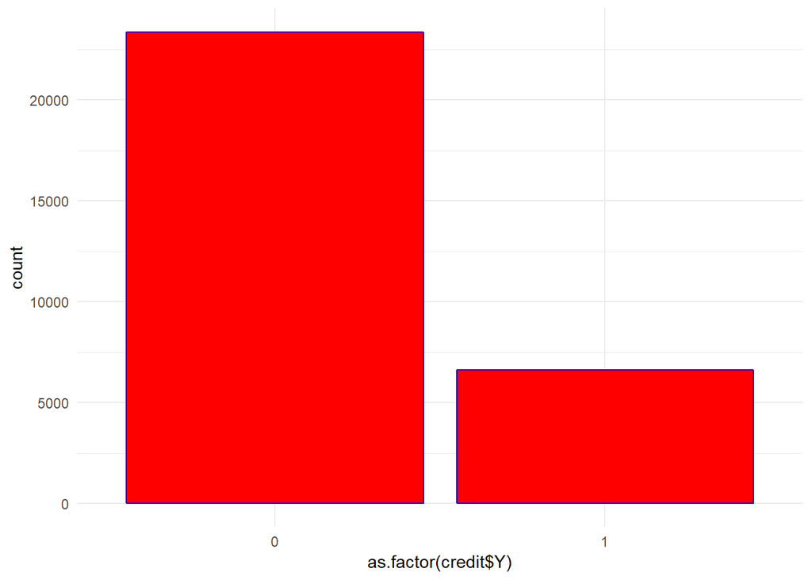

```r
#We will plot a bar chart showing the distribution of default customers.
ggplot(credit) + aes(x = as.factor(credit$Y)) + geom_bar(color="blue", fill="red")+theme_minimal()
```

From our review of the dataset we can see that the data has 24 variables and 30000 rows of data. We can also see that the data headers are not giving much insights on the data in the column. We will rename the headers of the dataset.

```r
# Rename the headers of the dataset
credit= rename(credit, Credit_Amount = X1, Gender = X2, Education = X3, Marital_status = X4,
               Age = X5,RepayS_0 = X6,RepayS_1 = X7, RepayS_2 = X8, RepayS_3 = X9,
               RepayS_4 = X10, RepayS_5 = X11, BillS_0 = X12, BillS_1 = X13,
               BillS_2 = X14, BillS_3 = X15,
               BillS_4 = X16, BillS_5 = X17,
               PrePay_0 = X18, PrePay_1 = X19,
              PrePay_2 = X20, PrePay_3 = X21,
                PrePay_4 = X22, PrePay_5 = X23,
               Default= Y)
data_c=credit
# Review the first 6 rows of credit dataset.
head(credit)
```

```
##   Credit_Amount Gender Education Marital_status Age RepayS_0 RepayS_1
## 1         20000      2         2              1  24        2        2
## 2        120000      2         2              2  26       -1        2
## 3         90000      2         2              2  34        0        0
## 4         50000      2         2              1  37        0        0
## 5         50000      1         2              1  57       -1        0
## 6         50000      1         1              2  37        0        0
##   RepayS_2 RepayS_3 RepayS_4 RepayS_5 BillS_0 BillS_1 BillS_2 BillS_3
## 1       -1       -1       -2       -2    3913    3102     689       0
## 2        0        0        0        2    2682    1725    2682    3272
## 3        0        0        0        0   29239   14027   13559   14331
## 4        0        0        0        0   46990   48233   49291   28314
## 5       -1        0        0        0    8617    5670   35835   20940
## 6        0        0        0        0   64400   57069   57608   19394
##   BillS_4 BillS_5 PrePay_0 PrePay_1 PrePay_2 PrePay_3 PrePay_4 PrePay_5
## 1       0       0        0      689        0        0        0        0
## 2    3455    3261        0     1000     1000     1000        0     2000
## 3   14948   15549     1518     1500     1000     1000     1000     5000
## 4   28959   29547     2000     2019     1200     1100     1069     1000
## 5   19146   19131     2000    36681    10000     9000      689      679
## 6   19619   20024     2500     1815      657     1000     1000      800
##   Default
## 1       1
## 2       1
## 3       0
## 4       0
## 5       0
## 6       0
```

```r
# We check if the dataset has any missing values by checking rows of data
credit[!complete.cases(credit),]
```

```
##  [1] Credit_Amount  Gender         Education      Marital_status
##  [5] Age            RepayS_0       RepayS_1       RepayS_2
##  [9] RepayS_3       RepayS_4       RepayS_5       BillS_0
## [13] BillS_1        BillS_2        BillS_3        BillS_4
## [17] BillS_5        PrePay_0       PrePay_1       PrePay_2
## [21] PrePay_3       PrePay_4       PrePay_5       Default
## <0 rows> (or 0-length row.names)
```

```r
#Let's check if there are duplicated data
dup_rows = duplicated(credit)
dup_rows_num = sum(dup_rows)
dup_rows_num
```

```
## [1] 35
```

```r
#here we remove the duplicate datapoints
credit = credit %>% distinct()
```

After renaming the header we will now further explore the data to see the relationship between various variables.

## Step 2: Exploratory Data Analysis

```r
# We perform descriptive statistics to understand the distribution of the data
describe(credit)
```

```
##                vars     n      mean        sd median   trimmed       mad
## Credit_Amount     1 29965 167442.01 129760.14 140000 151551.23 133434.00
## Gender            2 29965      1.60      0.49      2      1.63      0.00
## Education         3 29965      1.85      0.79      2      1.78      1.48
## Marital_status    4 29965      1.55      0.52      2      1.55      0.00
## Age               5 29965     35.49      9.22     34     34.69      8.90
## RepayS_0          6 29965     -0.02      1.12      0     -0.06      1.48
## RepayS_1          7 29965     -0.13      1.20      0     -0.20      0.00
## RepayS_2          8 29965     -0.16      1.20      0     -0.23      0.00
## RepayS_3          9 29965     -0.22      1.17      0     -0.30      0.00
## RepayS_4         10 29965     -0.26      1.13      0     -0.36      0.00
## RepayS_5         11 29965     -0.29      1.15      0     -0.39      0.00
## BillS_0          12 29965  51283.01  73658.13  22438  35422.71  32382.95
## BillS_1          13 29965  49236.37  71195.57  21295  33896.87  30993.75
## BillS_2          14 29965  47067.92  69371.35  20135  32122.39  29273.94
## BillS_3          15 29965  43313.33  64353.51  19081  29265.52  27696.45
## BillS_4          16 29965  40358.33  60817.13  18130  26970.42  26262.78
## BillS_5          17 29965  38917.01  59574.15  17124  25773.58  24919.54
## PrePay_0         18 29965   5670.10  16571.85   2102   3002.19   2859.94
## PrePay_1         19 29965   5927.98  23053.46   2010   2881.28   2950.37
## PrePay_2         20 29965   5231.69  17616.36   1804   2473.24   2662.75
## PrePay_3         21 29965   4831.62  15674.46   1500   2203.19   2223.90
## PrePay_4         22 29965   4804.90  15286.37   1500   2206.14   2223.90
## PrePay_5         23 29965   5221.50  17786.98   1500   2169.25   2223.90
## Default          24 29965      0.22      0.42      0      0.15      0.00
##                    min     max   range  skew kurtosis     se
## Credit_Amount    10000 1000000  990000  0.99     0.54 749.61
## Gender               1       2       1 -0.42    -1.82   0.00
## Education            0       6       6  0.97     2.08   0.00
## Marital_status       0       3       3 -0.02    -1.36   0.00
## Age                 21      79      58  0.73     0.04   0.05
## RepayS_0            -2       8      10  0.73     2.73   0.01
## RepayS_1            -2       8      10  0.79     1.58   0.01
## RepayS_2            -2       8      10  0.84     2.09   0.01
## RepayS_3            -2       8      10  1.00     3.51   0.01
## RepayS_4            -2       8      10  1.01     4.00   0.01
## RepayS_5            -2       8      10  0.95     3.44   0.01
## BillS_0        -165580  964511 1130091  2.66     9.79 425.51
## BillS_1         -69777  983931 1053708  2.70    10.29 411.29
## BillS_2        -157264 1664089 1821353  3.09    19.77 400.75
## BillS_3        -170000  891586 1061586  2.82    11.30 371.76
## BillS_4         -81334  927171 1008505  2.87    12.29 351.33
## BillS_5        -339603  961664 1301267  2.84    12.26 344.15
## PrePay_0             0  873552  873552 14.66   414.76  95.73
## PrePay_1             0 1684259 1684259 30.44  1639.54 133.18
## PrePay_2             0  896040  896040 17.21   563.61 101.77
## PrePay_3             0  621000  621000 12.90   276.98  90.55
## PrePay_4             0  426529  426529 11.12   179.83  88.31
## PrePay_5             0  528666  528666 10.63   166.94 102.75
## Default              0       1       1  1.34    -0.20   0.00
```

From the descriptive statistics we can see that 22% of the customers defaulted payment. Hence we will determine which variable to examine more closely by looking at its correlation with the target variable.

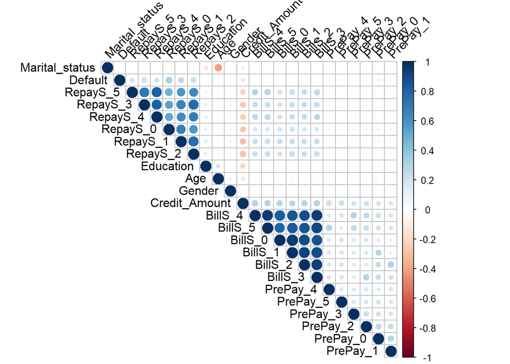

```r
# Correlation plot
res = cor(credit)
corrplot(res, type = "upper", order = "hclust",
         tl.col = "black", tl.srt = 45)
```

```r
status_table = table(credit$Default)
status_table
```

```
##
##     0     1
## 23335  6630
```

```r
#the percentage of people who default
(status_table["1"]/(status_table["0"]+status_table["1"]))*100
```

```
##        1
## 22.12581
```

From the data we can see 22.12% of the customers defaulted

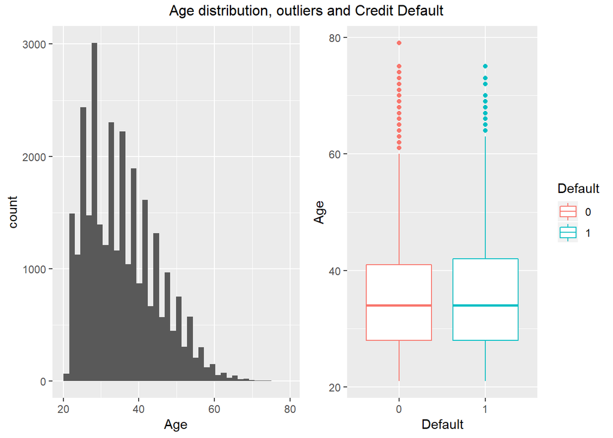

```r
credit$Default=factor(credit$Default)
# We will plot the distribution of credit default with age
g_Age_1 = ggplot(credit, aes(x=Age )) + geom_histogram(bins=40)
g_Age_2 = ggplot(credit, aes(x=Default, y=Age , col=Default)) + geom_boxplot()
grid.arrange(g_Age_1, g_Age_2,ncol=2, top='Age distribution, outliers and Credit Default')
```

From the chart above we can see the distribution of the population is skewed to the right the mean is greater than the median. This implies that majority of the population in our dataset are younger in age.

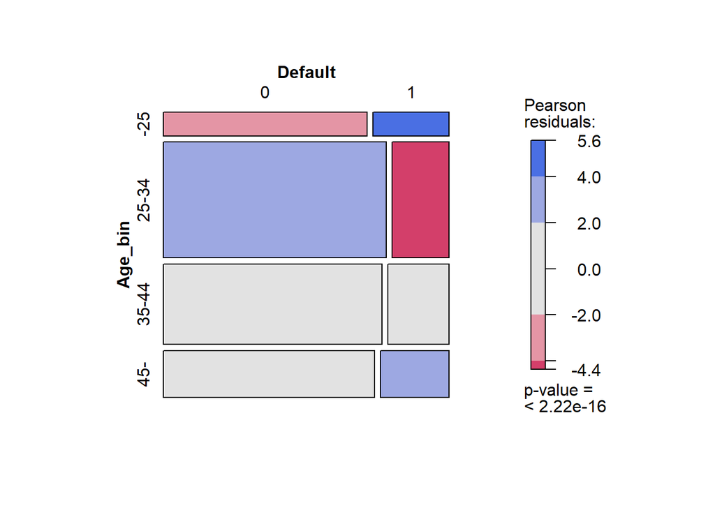

```r
# We will create bin for age
credit$Gender= if_else( credit$Gender == "1", "M","F")
credit$Gender=factor(credit$Gender)

data = credit %>%
              mutate(Age_bin = ifelse(Age < 25, "-25",
                             ifelse(Age < 35, "25-34",
                             ifelse(Age < 45, "35-44", "45-")))
                     )

# Generate mosaic diagrams with Chi-Square tests
library(vcd)
# Plot mosaic diagram with Chi-Square tests
mosaic(~ Age_bin + Default,data = data, shade=TRUE, legend=TRUE)
```

Based on our analysis we can see that customers under age 25 have the highest possibility of defaulting and age group 25 - 34 have the smallest possibility of defaulting.

```r
#We will plot the distribution of credit default with gender
tab_Gender = table(credit$Gender, credit$Default)
addmargins(tab_Gender)
```

```
##
##           0     1   Sum
##   F   14330  3761 18091
##   M    9005  2869 11874
##   Sum 23335  6630 29965
```

```r
prop.table(tab_Gender,2)
```

```
##
##            0        1
##   F 0.614099 0.567270
##   M 0.385901 0.432730
```

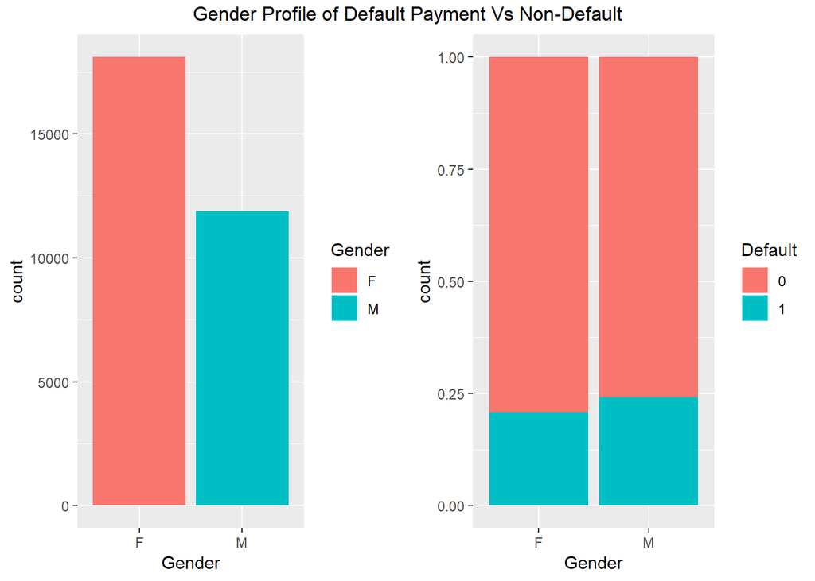

```r
g_Gender_1 = ggplot(credit, aes(x=Gender, fill=Gender)) + geom_bar(position="dodge")
g_Gender_2 = ggplot(credit, aes(x=Gender, fill=Default)) + geom_bar(position="fill")
grid.arrange(g_Gender_1, g_Gender_2,ncol=2, top='Gender Profile of Default Payment Vs Non-Default')
```

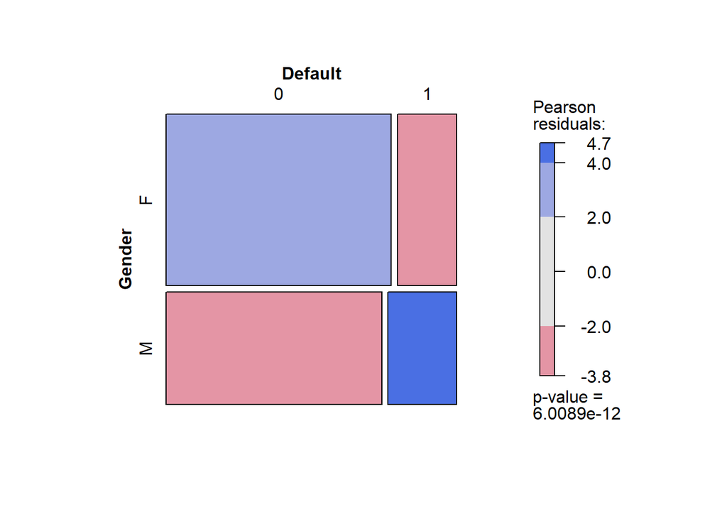

```r
# Plot mosaic diagram with Chi-Square tests
library(vcd)
mosaic(~ Gender + Default,data = data, shade=TRUE, legend=TRUE)
```

Based on our analysis we can see that male customers have a higher probability of defaulting compared to the female customers.

```r
#Understand the customer demography
credit$Education = if_else( credit$Education == "1", "Graduate_school",
                            if_else( credit$Education == "2", "University",
                                     if_else( credit$Education == "3", "High_school", "Others")))

credit$Marital_status= if_else( credit$Marital_status == "1", "Married",
                            if_else( credit$Marital_status == "2", "Single","Others"))
```

Here we will check the relationship between eduction and credit risk default

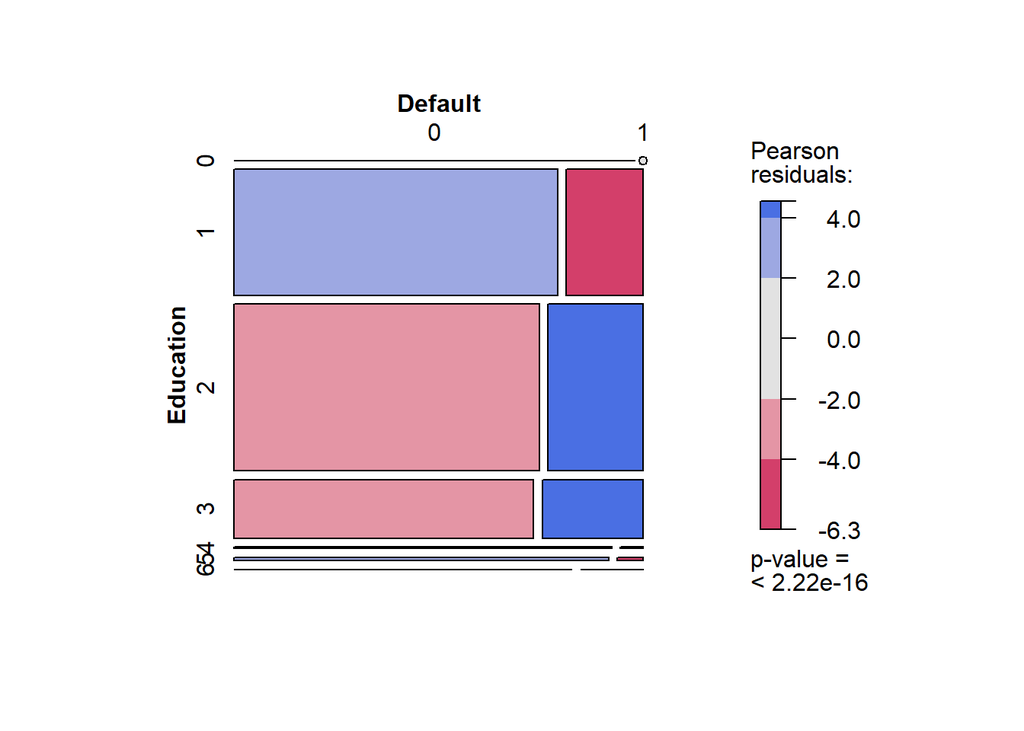

```r
# Plotting mosaic diagram with Chi-Square tests to understand the relationship between education and default
mosaic(~ Education + Default,data = data, shade=TRUE, legend=TRUE)
```

```r
#Let's check:
tab_education = table(credit$Default, credit$Education)
addmargins(tab_education)
```

```
##
##       Graduate_school High_school Others University   Sum
##   0              8531        3678    435      10691 23335
##   1              2032        1237     33       3328  6630
##   Sum           10563        4915    468      14019 29965
```

```r
#probability table
prop.table(tab_education,2)
```

```
##
##     Graduate_school High_school     Others University
##   0      0.80763041  0.74832146 0.92948718 0.76260789
##   1      0.19236959  0.25167854 0.07051282 0.23739211
```

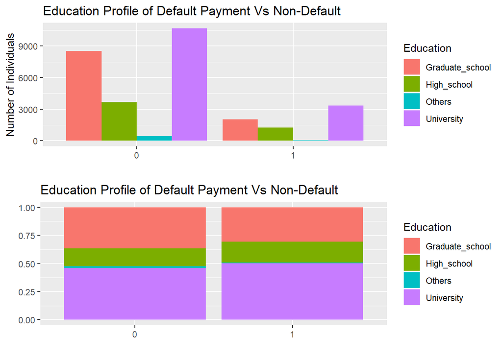

```r
library(ggplot2)
g_Education_1=ggplot(credit, aes(x = Default)) + geom_bar(aes (fill = Education), position = "dodge") +ggtitle("Education Profile of Default Payment Vs Non-Default")+  xlab("")+ylab("Number of Individuals")

g_Education_2=ggplot(credit, aes(x = Default)) + geom_bar(aes (fill = Education), position = "fill") + ggtitle("Education Profile of Default Payment Vs Non-Default")+  xlab("")+ylab("")

grid.arrange(g_Education_1, g_Education_2, nrow=2)
```

Based on our analysis we can see a correlation between education and default.Customers with higher degrees have a lower probability of defaulting compared to customers with other degrees. It can be seen that people with graduate school degree have a 19% probability of defaulting which is lower than the default risk for university 23.7% and high school degree 25.2%. We can see from above bar chart that number of customers having university education is highest, followed by customers having graduate school and high school in both the categories.

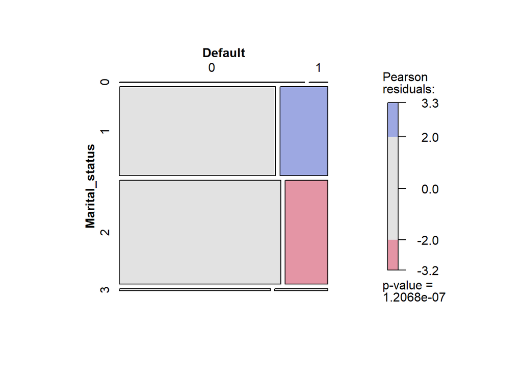

```r
# Plot mosaic diagram with Chi-Square tests to understand the relationship between marital status and default
mosaic(~ Marital_status+ Default,data = data, shade=TRUE, legend=TRUE)
```

```r
#Let's check:
tab_marital_status = table(credit$Marital_status, credit$Default)
addmargins(tab_marital_status)
```

```
##
##               0     1   Sum
##   Married 10442  3201 13643
##   Others    288    89   377
##   Single  12605  3340 15945
##   Sum     23335  6630 29965
```

```r
#probability table
prop.table(tab_marital_status,2)
```

```
##
##                    0          1
##   Married 0.44748232 0.48280543
##   Others  0.01234198 0.01342383
##   Single  0.54017570 0.50377074
```

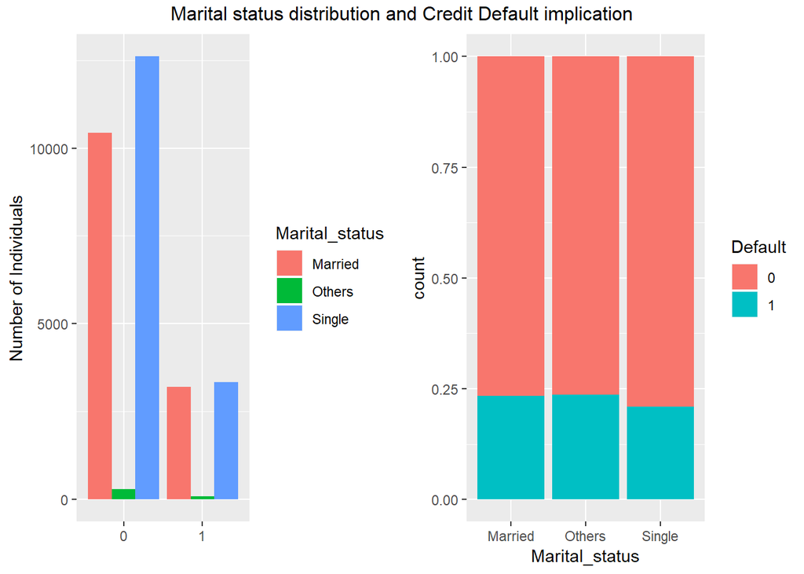

```r
g_marital_status_1=ggplot(credit, aes(x = Default)) + geom_bar(aes (fill = Marital_status), position = "dodge")+ xlab("")+ylab("Number of Individuals")

g_marital_status_2=g_Gender_2 = ggplot(credit, aes(x=Marital_status, fill=Default)) + geom_bar(position="fill")


grid.arrange(g_marital_status_1, g_marital_status_2, ncol=2,top='Marital status distribution and Credit Default implication')
```

Based on our analysis we can see that married customers have a higher probability of defaulting when compared to the single customers.

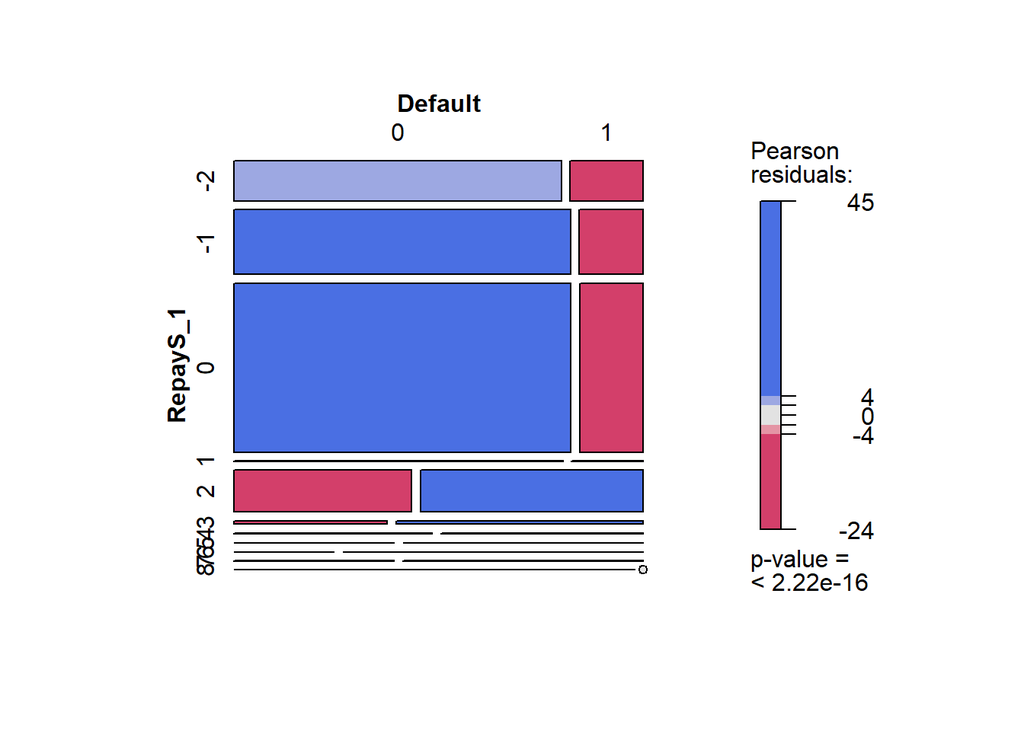

```r
# We check the relationship between repayment status and the default with Chi-Square tests
mosaic(~ RepayS_1 + Default,data = data, shade=TRUE, legend=TRUE)
```

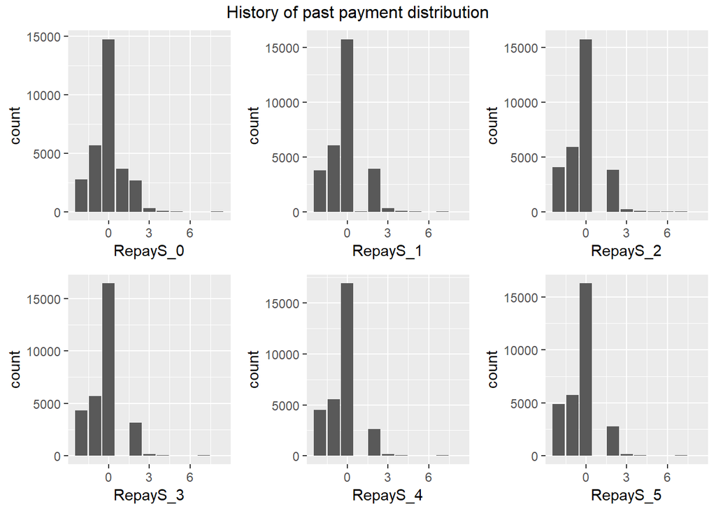

```r
#Let's see the distribution of History of past payment
g_RepayS_0 = ggplot(credit, aes(x=RepayS_0, fill=RepayS_0)) + geom_bar(position="dodge")
g_RepayS_1 = ggplot(credit, aes(x=RepayS_1, fill=RepayS_1)) + geom_bar(position="dodge")
g_RepayS_2 = ggplot(credit, aes(x=RepayS_2, fill=RepayS_2)) + geom_bar(position="dodge")
g_RepayS_3 = ggplot(credit, aes(x=RepayS_3, fill=RepayS_3)) + geom_bar(position="dodge")
g_RepayS_4 = ggplot(credit, aes(x=RepayS_4, fill=RepayS_4)) + geom_bar(position="dodge")
g_RepayS_5 = ggplot(credit, aes(x=RepayS_5, fill=RepayS_5)) + geom_bar(position="dodge")
grid.arrange(g_RepayS_0, g_RepayS_1,g_RepayS_2,g_RepayS_3,g_RepayS_4,g_RepayS_5,ncol=3, nrow = 2, top='History of past payment distribution')
```

This chart gives a history of past monthly payment records (from April to September, 2005) for the customers. It can be seen that any customers pay their liability as at when due but there are customers who have payment delay of 2 months and above. Customers who have delayed payment of at least 1 month in any of the previous months, have an increased chance of default.

## Step 3: Feature engineering and selection

Feature engineering is the combining of different attributes and variables in the dataset to get more value. In general, an engineered feature may be easier for a machine learning algorithm to digest and make rules from than the variables it was derived from.

```r
head(credit)
```

```
##   Credit_Amount Gender       Education Marital_status Age RepayS_0
## 1         20000      F      University        Married  24        2
## 2        120000      F      University         Single  26       -1
## 3         90000      F      University         Single  34        0
## 4         50000      F      University        Married  37        0
## 5         50000      M      University        Married  57       -1
## 6         50000      M Graduate_school         Single  37        0
##   RepayS_1 RepayS_2 RepayS_3 RepayS_4 RepayS_5 BillS_0 BillS_1 BillS_2
## 1        2       -1       -1       -2       -2    3913    3102     689
## 2        2        0        0        0        2    2682    1725    2682
## 3        0        0        0        0        0   29239   14027   13559
## 4        0        0        0        0        0   46990   48233   49291
## 5        0       -1        0        0        0    8617    5670   35835
## 6        0        0        0        0        0   64400   57069   57608
##   BillS_3 BillS_4 BillS_5 PrePay_0 PrePay_1 PrePay_2 PrePay_3 PrePay_4
## 1       0       0       0        0      689        0        0        0
## 2    3272    3455    3261        0     1000     1000     1000        0
## 3   14331   14948   15549     1518     1500     1000     1000     1000
## 4   28314   28959   29547     2000     2019     1200     1100     1069
## 5   20940   19146   19131     2000    36681    10000     9000      689
## 6   19394   19619   20024     2500     1815      657     1000     1000
##   PrePay_5 Default
## 1        0       1
## 2     2000       1
## 3     5000       0
## 4     1000       0
## 5      679       0
## 6      800       0
```

```r
# We look at the classes of the education
ed_table= credit %>% dplyr::select(Education, Default) %>% table()

prop_results = as_tibble(prop.table(ed_table,1))
prop_results
```

```
## # A tibble: 8 x 3
##   Education       Default      n
##   <chr>           <chr>    <dbl>
## 1 Graduate_school 0       0.808
## 2 High_school     0       0.748
## 3 Others          0       0.929
## 4 University      0       0.763
## 5 Graduate_school 1       0.192
## 6 High_school     1       0.252
## 7 Others          1       0.0705
## 8 University      1       0.237
```

It can be seen that customers with only high school degree and university degree has a higher probability of defaulting compared to customers who went to graduate school and others.

```r
#We will bucket the age
credit %>% dplyr::select(Age) %>% summary()
```

```
##       Age
##  Min.   :21.00
##  1st Qu.:28.00
##  Median :34.00
##  Mean   :35.49
##  3rd Qu.:41.00
##  Max.   :79.00
```

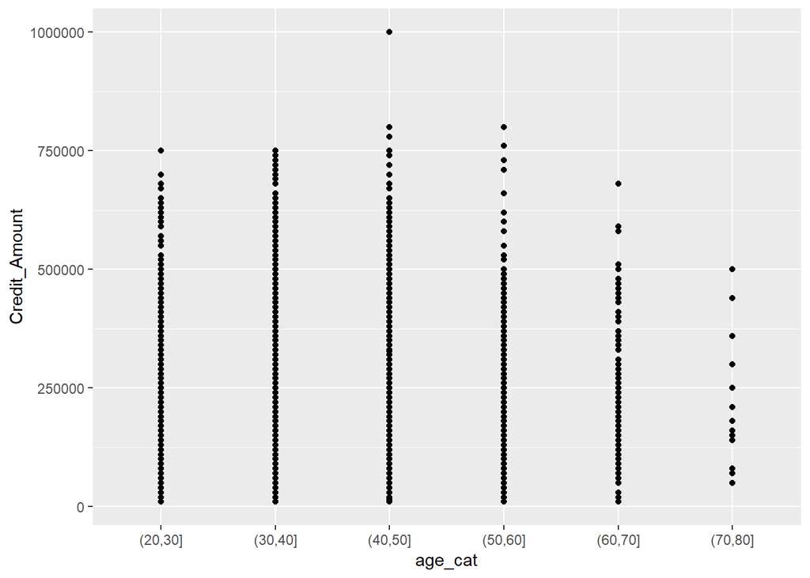

```r
# We will use sequnce function to generate age buckets
credit =credit %>% mutate(age_cat = cut(Age, breaks = seq(20,80, by =10)))
ggplot(credit, aes(x=age_cat, y=Credit_Amount)) + geom_point()
```

```r
#We will bucket the Credit amount using quantile bucketing to generate credit limit buckets
credit_new=credit
credit_new %>% dplyr::select(Credit_Amount) %>% summary()
```

```
##  Credit_Amount
##  Min.   :  10000
##  1st Qu.:  50000
##  Median : 140000
##  Mean   : 167442
##  3rd Qu.: 240000
##  Max.   :1000000
```

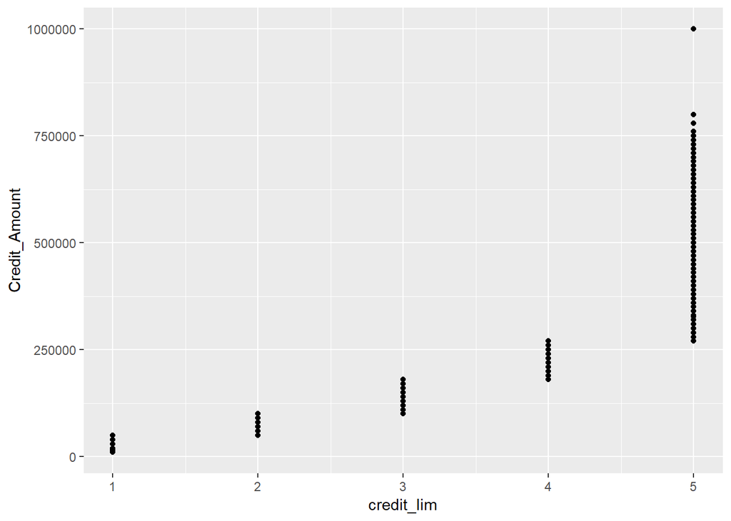

```r
credit_new=credit_new %>% mutate(credit_lim = ntile(Credit_Amount, 5))
ggplot(credit_new, aes(x=credit_lim, y=Credit_Amount)) +
    geom_point()
```

```r
sqldf("select credit_lim, min(Credit_Amount),max(Credit_Amount) from credit_new group by credit_lim")
```

```
##   credit_lim min(Credit_Amount) max(Credit_Amount)
## 1          1              10000              50000
## 2          2              50000             100000
## 3          3             100000             180000
## 4          4             180000             270000
## 5          5             270000            1000000
```

```r
#Create a new variable to calculate average repayment status
credit_new$Average_Repay_S= (credit_new$RepayS_0+credit_new$RepayS_1+ credit_new$RepayS_2 + credit_new$RepayS_3 + credit_new$RepayS_4 + credit_new$RepayS_5)/6
# Running or cumulative sum of bill amount - payment amount for each individual
credit_new$Amount_owed = credit_new$BillS_0 + credit_new$BillS_1 + credit_new$BillS_2 + credit_new$BillS_3 + credit_new$BillS_4 + credit_new$BillS_5 - credit$PrePay_0 - credit$PrePay_1 - credit$PrePay_2 - credit$PrePay_3 - credit$PrePay_4 - credit$PrePay_5

#Mean value of Amount owed over a 6 month period
credit_new$AVG_6MTH_BAL = credit_new$Amount_owed/6

#Average 6 month balance divided by the individual’s credit limit
credit_new$Bal_Lim_Ratio= round(credit_new$AVG_6MTH_BAL/credit_new$Credit_Amount,3)

data=credit_new
data$Gender= as.factor(data$Gender)
data$Education = as.factor(data$Education)
data$RepayS_0=as.factor(data$RepayS_0)
data$RepayS_1=as.factor(data$RepayS_1)
data$RepayS_2=as.factor(data$RepayS_2)
data$RepayS_3=as.factor(data$RepayS_3)
data$RepayS_4=as.factor(data$RepayS_4)
data$RepayS_5=as.factor(data$RepayS_5)
data$Marital_status= as.factor(data$Marital_status)
data$age_cat = as.factor(data$age_cat)
data$Age=NULL
data$Credit_Amount=NULL
```

One-Hot Encoding We converted categorical variables into a form of binary variable for each unique integer value where we applied algorithms to do predictions.

```r
# Hot encoding: dummify the data
credit_new = dummy.data.frame(credit_new, names=c("Gender","Education", "Marital_status", "credit_lim"), sep="_")

credit_new = dummy.data.frame(credit_new, names=c("age_cat"), sep="_")
```